# SMS spam prediciton

Lovdip Singh

## Goal of study

To create a model which predicts spam from non spam messages using SMS message data.

## Decision tree

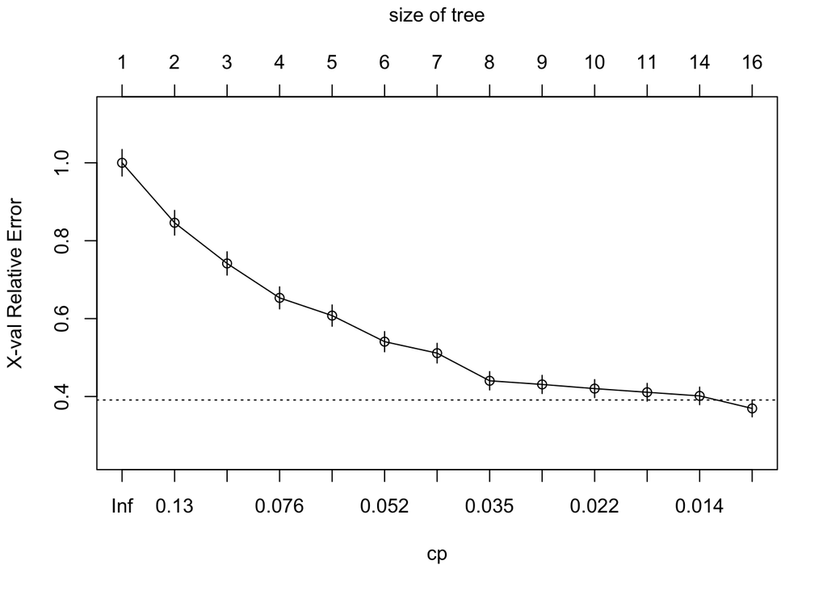

```r
load("spam.rda")

# factor class labels
df$is_spam <- df$is_spam %>%
  as.factor() %>%
  fct_recode(spam="TRUE",
             non_spam="FALSE") %>%
  fct_relevel("spam")

# tibble for  data
spam <- as_tibble(cbind(as_tibble(wordmatrix), is_spam=df$is_spam))

# tree r part does 10 fold cross validation by default
spam_tree <- rpart(is_spam~., data=spam)
plotcp(spam_tree)
```

```r
printcp(spam_tree)
```

```
##
## Classification tree:
## rpart(formula = is_spam ~ ., data = spam)
##
## Variables actually used in tree construction:
##  [1] w_awarded    w_Call       w_claim      w_collection w_Free
##  [6] w_FREE       w_me         w_mobile     w_PO         w_Reply
## [11] w_service    w_STOP       w_Text       w_Txt        w_www
##
## Root node error: 747/5574 = 0.13402
##
## n= 5574
##
##          CP nsplit rel error  xerror     xstd
## 1  0.153949      0   1.00000 1.00000 0.034048
## 2  0.104418      1   0.84605 0.84605 0.031689
## 3  0.088353      2   0.74163 0.74163 0.029902
## 4  0.065596      3   0.65328 0.65328 0.028248
## 5  0.060241      4   0.58768 0.60776 0.027338
## 6  0.044177      5   0.52744 0.54083 0.025914
## 7  0.042838      6   0.48327 0.51138 0.025252
## 8  0.028112      7   0.44043 0.44043 0.023554
## 9  0.022758      8   0.41232 0.43106 0.023318
## 10 0.021419      9   0.38956 0.42035 0.023044
## 11 0.014279     10   0.36814 0.41098 0.022801
## 12 0.013387     13   0.32530 0.40161 0.022554
## 13 0.010000     15   0.29853 0.36948 0.021682
```

0.01 is a good complexity parameter, prune tree accordingly.

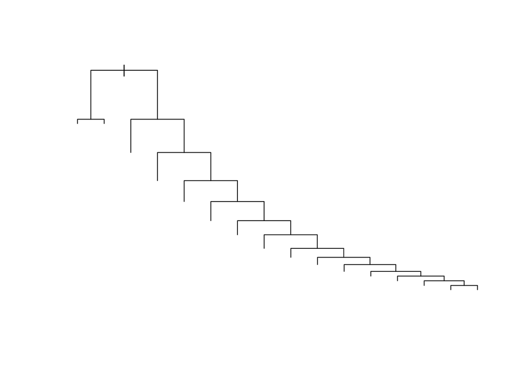

```r
spam_tree_pruned <- prune(spam_tree, 0.01)
plot(spam_tree_pruned)
```

There are multiple branches to the right of the tree. The length of the branches represents improvement in classification based on the Gini impurity index, these appear to decrease with increasing tree depth. This suggests that the order of importance for words most indicative of spam appear at the top of the tree, and the least indicitive towards the bottom. If the last condition on the right most node is not met, the text is classified as non-spam.

## Prediction

```r
# confusion matrix using rpart cv
pred <- xpred.rpart(spam_tree)[,13]
pred <- as.character(pred) %>%
  as.factor() %>%
  fct_recode(spam='1',
             non_spam='2') %>%
  fct_relevel("spam")

with(spam,
     table(actual=is_spam,
           predicted=pred))
```

```
##           predicted
## actual     spam non_spam
##   spam      537      210
##   non_spam   62     4765
```

From the confusion matrix we can calculate the following rates:

- False positive rate: 1.28%
- False negative rate: 28.11%
- Overall accuracy: 95.12%

## Naive Bayes

To classify texts as spam a approximate naive Bayes classifier will be trained. 10 fold cross validation will be used get a low biased estimate of the classifiers performance on unseen data.

In this data set the classes are unbalanced there are about 13% spam messages, leaving 87% as non-spam. Therefore stratified sampling will be used to determine the folds to ensure that each fold has a similar proportion of classes as the whole data set.

```r
# stratified sampling for 10 folds
library(caret)
folds <- createFolds(spam$is_spam, k = 10, list = FALSE)
spam$fold <- folds

spam %>% group_by(fold, is_spam) %>%
  summarise(n = n()) %>%
  mutate(prop = n / sum(n))
```

```
## # A tibble: 20 x 4
## # Groups:   fold [10]
##     fold is_spam      n  prop
##    <int> <fct>    <int> <dbl>
##  1     1 spam        74 0.133
##  2     1 non_spam   482 0.867
##  3     2 spam        75 0.134
##  4     2 non_spam   483 0.866
##  5     3 spam        75 0.134
##  6     3 non_spam   483 0.866
##  7     4 spam        75 0.134
##  8     4 non_spam   483 0.866
##  9     5 spam        75 0.134
## 10     5 non_spam   483 0.866
## 11     6 spam        74 0.133
## 12     6 non_spam   483 0.867
## 13     7 spam        75 0.135
## 14     7 non_spam   482 0.865
## 15     8 spam        74 0.133
## 16     8 non_spam   483 0.867
## 17     9 spam        75 0.135
## 18     9 non_spam   482 0.865
## 19    10 spam        75 0.134
## 20    10 non_spam   483 0.866
```

```r
thresholds <- numeric(10)
cms <- vector(mode="list", length=10)

for (i in 1:10){

  # assign 1 fold for test and rest for training
  test <- spam %>% filter(fold==i)
  train <- spam %>% filter(fold!=i)

  # y_i word occurrences for spam
  y_i <- train %>%
    filter(is_spam=='spam') %>%
    select(-is_spam, -fold) %>%
    colSums() %>%
    as.numeric()

  # n_i word occurrences for non-spam
  n_i <- train %>%
    filter(is_spam=='non_spam') %>%
    select(-is_spam, -fold) %>%
    colSums() %>%
    as.numeric()

  # evidence for each common word
  e_i <- log(y_i + 1) - log(n_i + 1)
  e_i <- as.matrix(e_i)


  # apply model to test data
  e <- as.matrix(test[,c(-631,-632)]) %*% e_i

  pred <- tibble(e=as.numeric(e), actual=test$is_spam) %>%
    arrange(desc(e))
  # determining threshold for same proportion classified as observed
  n <- sum(test$is_spam=='spam')
  threshold <- mean(as.numeric(pred[n,1]),
                    as.numeric(pred[n+1,1]))
  thresholds[i] <- threshold




  # predict based on threshold
  pred <- pred %>% mutate(predicted=ifelse(e >= threshold, "spam", "non-spam"))
  pred$predicted <- pred$predicted %>%
    as.factor() %>%
    fct_relevel("spam")

  # confusion matrix
  cms[[i]] <- with(pred, table(actual=actual, predicted=predicted))
}


thresholds
```

```
##  [1] -6.155566 -7.270426 -6.509075 -5.847931 -7.065730 -6.423599 -5.853160
##  [8] -6.987975 -7.043746 -7.090679
```

```r
round(mean(thresholds), 3)
```

```
## [1] -6.625
```

```r
# confusion matrix for all folds
Reduce('+',cms)
```

```
##           predicted
## actual     spam non-spam
##   spam      408      339
##   non_spam  339     4488
```

The average threshold for classifying text as spam was values of evidence greater than -6.625 for a given text.

## Limitations

Spam/non-spam accuracy is likely to be higher in this data set compared to real life. This can attributed to the collection methods of the data set. For example some spam was collected from a forum, this would not be a representative sample of all spam messages as those that are reported are likely to be the most extreme ones as as an average person would not go through the extent, or have the knowledge to report spam to this forum. Furthermore, the non-spam messages were mainly from student text messages in singaporean english, this means our classifier, and potentially other classifiers, are biased towards this population and may not be generalisable to other populations such as elderly users, as their patterns of words used are likely to be different. Overall, the accuracy of our model is likely to be higher as there is a larger difference in words used between spam and non-spam messages due to the sources of these messages in the data set, which in turn, makes the classifier have a higher accuracy and hence may not be generalisable to other populations.